# (Effects on the trip duration)

## by (Gamal Samir Ali Abdalluh Shouman)

## Investigation Overview

> i focused on these features (member birth year, member gender, distance, day of week,user type) to show if the rider and trip informations that could be used to predict the trip duration.

## Dataset Overview

> There are 170839 trips in this dataset with 18 features('duration_sec', 'start_time', 'end_time', 'start_station_id', 'start_station_name', 'start_station_latitude','start_station_longitude', 'end_station_id', 'end_station_name', 'end_station_latitude', 'end_station_longitude', 'bike_id', 'user_type','member_birth_year', 'member_gender', 'bike_share_for_all_trip','distance_Km', 'day_of_week') these trips happened in the period between febreuary and march in 2019. There were some missing values, trips with distances equal 0 and some illogical values in the `member_birth_year` like (1878, 1910, 1920,....etc) so, i removed all these values.

## (The duration)

> Most of the trips have small duration. The log-scale of the duration the distribution looks uinmodle and its peak at 500 seconds. After 10k second there are some outliers.

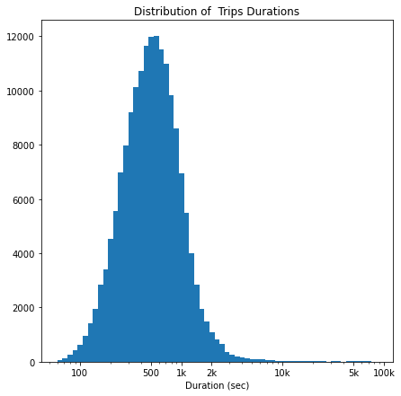

## (the distance)

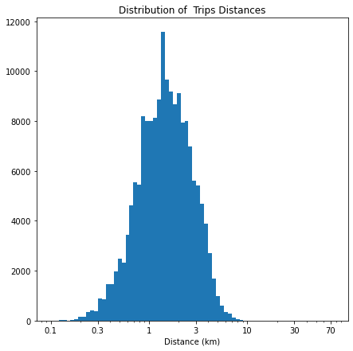

## (member_birth-year)

> - In the figure of member_birth-year we find that most of the riders were born in 1980s or 1990s and a few of them were born 1950s to 1970s.

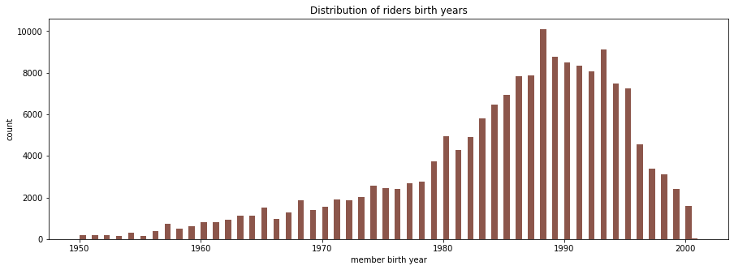

## (Trips over the weekdays)

We find that Thursday is the most crowded day and the lowest number of trips is in Sunday The count of bike share is very less than bikes were not shared

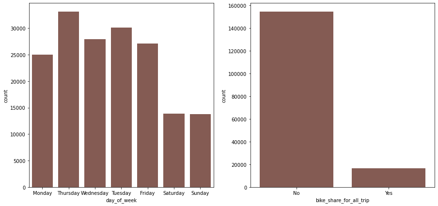

## Duration vs. Trip Distance

there is a strong positive correlation between the duration and distance variable when they were plotted in the log-scale.

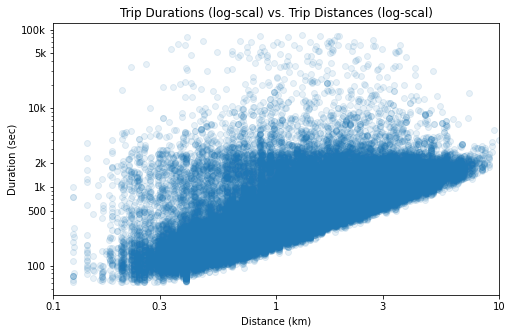

## distance and Duration by User Type

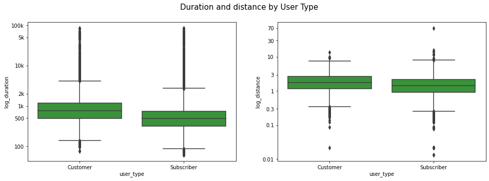

## Distance and Duration by User Type & Weekdays

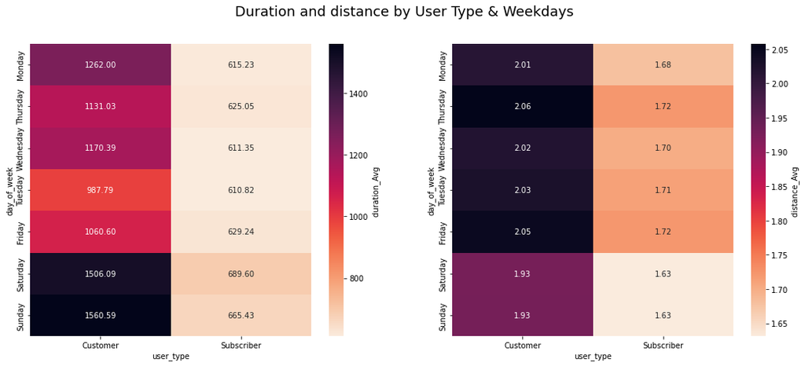

## Distance and Duration by riders gender & Weekdays

"other" has the highest average duration and distanc and males have the lowest

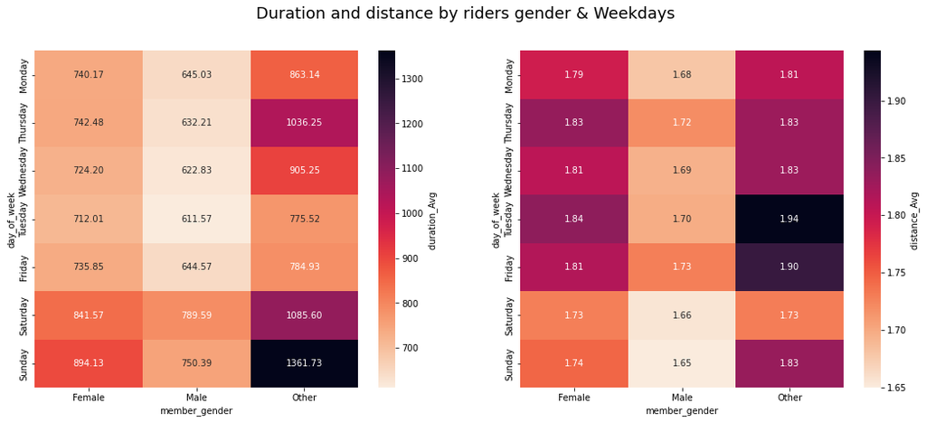

[output not shown]